# Statistička analiza podataka - Projekt Analiza čimbenika rizika za srčane bolesti

Saprofiti

2025-01-16

```r
library(dplyr)
```

```r
library(ggplot2)
library(magrittr)
library(tidyr)
library(readr)
```

# Učitavanje podataka

```r
data <- read_csv("heart.csv")
```

### DESKRIPTIVNA STATISTIKA i VIZUALIZACIJA

# Prikaz prvih 6 redova

```r
head(data)
```

```
## # A tibble: 6 × 12
##     Age Sex   ChestPainType RestingBP Cholesterol FastingBS RestingECG MaxHR
##   <dbl> <chr> <chr>             <dbl>       <dbl>     <dbl> <chr>      <dbl>
## 1    40 M     ATA                 140         289         0 Normal       172
## 2    49 F     NAP                 160         180         0 Normal       156
## 3    37 M     ATA                 130         283         0 ST            98
## 4    48 F     ASY                 138         214         0 Normal       108
## 5    54 M     NAP                 150         195         0 Normal       122
## 6    39 M     NAP                 120         339         0 Normal       170
## # ℹ 4 more variables: ExerciseAngina <chr>, Oldpeak <dbl>, ST_Slope <chr>,
## #   HeartDisease <dbl>
```

# Opis značajki

AGE -> Age of the patient [years] Sex -> Sex of the patient [M: Male, F: Female] ChestPainType -> chest pain type [TA: Typical Angina, ATA: Atypical Angina, NAP: Non-Anginal Pain, ASY: Asymptomatic] RestingBP -> Resting blood pressure [mm Hg] Cholesterol -> Serum cholesterol [mm/dl] FastingBS -> Fasting blood sugar [1: if Fasting blood sugar > 120 mg/dl, 0: otherwise] RestingECG -> Resting electrocardiogram results [Normal: Normal, ST: having ST-T wave abnormality (T wave inversions and/or ST elevation or depression of > 0.05 mV), LVH: showing probable or definite left ventricular hypertrophy by Estes’ criteria] MaxHR -> Maximum heart rate achieved [Numeric value between 60 and 202] ExerciseAngina -> Exercise-induced angina [Y: Yes, N: No] Oldpeak -> Exercise-induced ST depression [ST depression induced by exercise relative to rest] ST_Slope -> Slope of the peak exercise ST segment [Up: upsloping, Flat: flat, Down: downsloping] HeartDisease -> Output class [1: heart disease, 0: Normal]

# Opis podataka

```r
dim(data)  # broj redaka, broj stupaca (broj primjera, broj varijabli)
```

```
## [1] 918  12
```

```r
cat("Number of rows: ", nrow(data), "\n")
```

```
## Number of rows:  918
```

```r
cat("Number of columns: ", ncol(data), "\n")
```

```
## Number of columns:  12
```

```r
cat("Column names:", paste(colnames(data), collapse = ", "), "\n")
```

```
## Column names: Age, Sex, ChestPainType, RestingBP, Cholesterol, FastingBS, RestingECG, MaxHR, ExerciseAngina, Oldpeak, ST_Slope, HeartDisease
```

# Monotone i konstantne vrijednosti

```r
cat("Number of rows is ", nrow(data), "\n")
```

```
## Number of rows is  918
```

```r
for (column in colnames(data)){
  cat("Column: ", column, "has ", length(unique(data[[column]])), " unique values\n")
}
```

```
## Column:  Age has  50  unique values
## Column:  Sex has  2  unique values
## Column:  ChestPainType has  4  unique values
## Column:  RestingBP has  67  unique values
## Column:  Cholesterol has  222  unique values
## Column:  FastingBS has  2  unique values
## Column:  RestingECG has  3  unique values
## Column:  MaxHR has  119  unique values
## Column:  ExerciseAngina has  2  unique values
## Column:  Oldpeak has  53  unique values
## Column:  ST_Slope has  3  unique values
## Column:  HeartDisease has  2  unique values
```

Pošto je broj jedinstvenih vrijednosti za svaku značajku manji od broja redaka, možemo zaključiti da nema monotone vrijednosti (napomena: provjerili smo i ručno kako se ne bi dogodilo da zbog nedostajućih vrijednosti izgleda kao da nema monotonih vrijednosti). Također, vidimo da nema ni konstantnih vrijednosti jer je broj jedinstvenih vrijednosti za svaku značajku veći od 1.

# Nedostajuće vrijednosti

```r
data %>% is.na() %>% colSums()
```

```
##            Age            Sex  ChestPainType      RestingBP    Cholesterol
##              0              0              0              0              0
##      FastingBS     RestingECG          MaxHR ExerciseAngina        Oldpeak
##              0              0              0              0              0
##       ST_Slope   HeartDisease
##              0              0
```

Nema nedostajućih vrijednosti, pa preskačemo korak zamjene nedostajućih vrijednosti

```r
data$Cholesterol[data$Cholesterol == 0] <- mean(data$Cholesterol[data$Cholesterol != 0])
```

Među podacima o kolesterolu postoje vrijednosti 0 koje predstavljaju nedsotatak tog podatka. Kako ove vrijednosti ne bi utjecale na ostatak testova vezanih uz kolesterol, njih smo odlučili zamijeniti srednjom vrijednošću ostatka kolesterola.

# Transformiranje kategoričkih značajki u numeričke

Mogli smo koristiti i one-hot encoding za neke značajke, no smatramo da ipak između svih značajki postoji neko uređenje te smo se zato odlučili za label encoding (npr. za značajku ChestPainType može biti TA -> ATA -> NAP -> ASY gdje određeni simptomi postaju manje karakteristični za anginu; ST_Slope također ima uređenje up -> flat -> down)

```r
cat(unique(data$Sex), "\n")
```

```
## M F
```

```r
oldCategoricalData <- data
data$Sex <- as.numeric(factor(data$Sex, levels = c("F", "M"), labels = c(0, 1))) - 1
data$ExerciseAngina <- as.numeric(factor(data$ExerciseAngina, levels = c("N", "Y"), labels = c(0, 1))) - 1
data$ChestPainType <- as.numeric(factor(data$ChestPainType, levels = c("TA", "ATA", "NAP", "ASY"), labels = c(0, 1, 2, 3)))
data$RestingECG <- as.numeric(factor(data$RestingECG, levels = c("Normal", "ST", "LVH"), labels = c(0, 1, 2)))
data$ST_Slope <- as.numeric(factor(data$ST_Slope, levels = c("Up", "Flat", "Down"), labels = c(0, 1, 2)))
```

# Nastavak deskriptivne statistike

Sada kad smo očistili podatke, možemo nastaviti s deskriptivnom statistikom. Prvo ćemo izvući osnovne statistike za podatke kao što su minimum, maksimum, kvantili i srednja vrijednost za numeričke podatke i učestalost pojavljivanja po kategorijama za kategoričke.

```r
data[-c(2,3,6,7,9,11,12)] %>% summary()
```

```
##       Age          RestingBP      Cholesterol        MaxHR
##  Min.   :28.00   Min.   :  0.0   Min.   : 85.0   Min.   : 60.0
##  1st Qu.:47.00   1st Qu.:120.0   1st Qu.:214.0   1st Qu.:120.0
##  Median :54.00   Median :130.0   Median :244.6   Median :138.0
##  Mean   :53.51   Mean   :132.4   Mean   :244.6   Mean   :136.8
##  3rd Qu.:60.00   3rd Qu.:140.0   3rd Qu.:267.0   3rd Qu.:156.0
##  Max.   :77.00   Max.   :200.0   Max.   :603.0   Max.   :202.0
##     Oldpeak
##  Min.   :-2.6000
##  1st Qu.: 0.0000
##  Median : 0.6000
##  Mean   : 0.8874
##  3rd Qu.: 1.5000
##  Max.   : 6.2000
```

```r
# učestalost pojavljivanja vrijednosti za kategoričke značajke
for (column in c(2, 3, 6, 7, 9, 11, 12)) {
  column_name <- colnames(oldCategoricalData)[column]
  column_values <- oldCategoricalData[[column]]
  cat("Column:", column_name, "has values:\n")
  print(table(column_values))
  cat("\n")
}
```

```
## Column: Sex has values:
## column_values
##   F   M
## 193 725
##
## Column: ChestPainType has values:
## column_values
## ASY ATA NAP  TA
## 496 173 203  46
##
## Column: FastingBS has values:
## column_values
##   0   1
## 704 214
##
## Column: RestingECG has values:
## column_values
##    LVH Normal     ST
##    188    552    178
##
## Column: ExerciseAngina has values:
## column_values
##   N   Y
## 547 371
##
## Column: ST_Slope has values:
## column_values
## Down Flat   Up
##   63  460  395
##
## Column: HeartDisease has values:
## column_values
##   0   1
## 410 508
```

# Račun mjera centralne tendencije i rasipanja numeričkih podataka u raznim kombinacijama

## Analiza podataka ovisno o spolu

```r
library(tidyverse)
data %>% group_by(Sex) %>% summarise(
  NumOfPatients = n(),
  HeartDiseaseRatio = sum(HeartDisease)/n(),
  FastingBSRatio = sum(FastingBS)/n(),
  ExerciseAnginaRatio = sum(ExerciseAngina)/n(),
  Mean.Age = mean(Age),
  Med.Age = median(Age),
  Mean.RestingBP = mean(RestingBP),
  Med.RestingBP = median(RestingBP),
  StdDev.RestingBP = sd(RestingBP),
  Mean.Cholesterol = mean(Cholesterol),
  StdDev.Cholesterol = sd(Cholesterol),
  Med.Cholesterol = median(Cholesterol),
  Mean.MaxHR = mean(MaxHR),
  StdDev.MaxHR = sd(MaxHR),
  Med.MaxHR = median(MaxHR),
  Mean.OldPeak = mean(Oldpeak),
  StdDev.OldPeak = sd(Oldpeak),
  Med.OldPeak = median(Oldpeak)
)
```

```
## # A tibble: 2 × 19
##     Sex NumOfPatients HeartDiseaseRatio FastingBSRatio ExerciseAnginaRatio
##   <dbl>         <int>             <dbl>          <dbl>               <dbl>
## 1     0           193             0.259          0.135               0.223
## 2     1           725             0.632          0.259               0.452
## # ℹ 14 more variables: Mean.Age <dbl>, Med.Age <dbl>, Mean.RestingBP <dbl>,
## #   Med.RestingBP <dbl>, StdDev.RestingBP <dbl>, Mean.Cholesterol <dbl>,
## #   StdDev.Cholesterol <dbl>, Med.Cholesterol <dbl>, Mean.MaxHR <dbl>,
## #   StdDev.MaxHR <dbl>, Med.MaxHR <dbl>, Mean.OldPeak <dbl>,
## #   StdDev.OldPeak <dbl>, Med.OldPeak <dbl>
```

Možemo prvo analizirati boxplotovima.

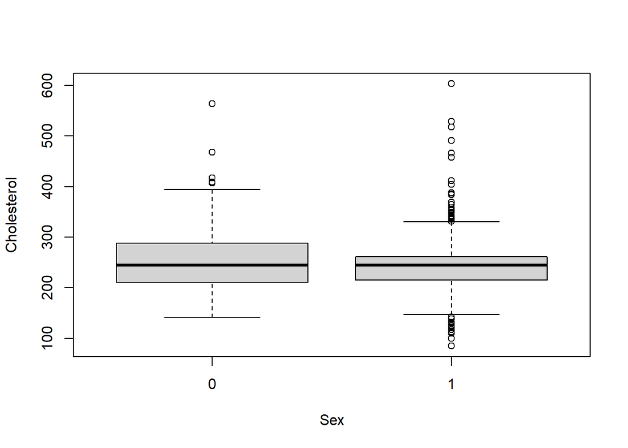

```r
boxplot(Cholesterol ~ Sex, data = data)
```

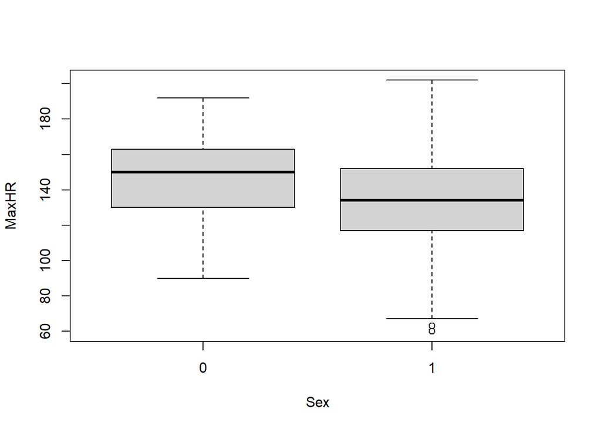

```r
boxplot(MaxHR ~ Sex, data = data)
```

## Analiza podataka s obzirom na dob

```r
library(tidyverse)

helperData <- data
dataWithAgeCategory <- helperData %>% mutate(ageCategory = cut(data$Age,
                      breaks = c(0, 30, 50, 70, 90, 120),  # Define the break points
                      labels = c("Category-1", "Category-2", "Category-3", "Category-4", "Category-5"),
                      right = TRUE))


dataWithAgeCategory %>% group_by(ageCategory) %>% summarise(
  NumOfPatients = n(),
  HeartDiseaseRatio = sum(HeartDisease)/n(),
  FastingBSRatio = sum(FastingBS)/n(),
  ExerciseAnginaRatio = sum(ExerciseAngina)/n(),
  Mean.Age = mean(Age),
  Med.Age = median(Age),
  Mean.RestingBP = mean(RestingBP),
  Med.RestingBP = median(RestingBP),
  StdDev.RestingBP = sd(RestingBP),
  Mean.Cholesterol = mean(Cholesterol),
  StdDev.Cholesterol = sd(Cholesterol),
  Med.Cholesterol = median(Cholesterol),
  Mean.MaxHR = mean(MaxHR),
  StdDev.MaxHR = sd(MaxHR),
  Med.MaxHR = median(MaxHR),
  Mean.OldPeak = mean(Oldpeak),
  StdDev.OldPeak = sd(Oldpeak),
  Med.OldPeak = median(Oldpeak)
)
```

```
## # A tibble: 4 × 19
##   ageCategory NumOfPatients HeartDiseaseRatio FastingBSRatio ExerciseAnginaRatio
##   <fct>               <int>             <dbl>          <dbl>               <dbl>
## 1 Category-1              5             0              0                   0
## 2 Category-2            311             0.402          0.116               0.280
## 3 Category-3            578             0.635          0.294               0.471
## 4 Category-4             24             0.667          0.333               0.5
## # ℹ 14 more variables: Mean.Age <dbl>, Med.Age <dbl>, Mean.RestingBP <dbl>,
## #   Med.RestingBP <dbl>, StdDev.RestingBP <dbl>, Mean.Cholesterol <dbl>,
## #   StdDev.Cholesterol <dbl>, Med.Cholesterol <dbl>, Mean.MaxHR <dbl>,
## #   StdDev.MaxHR <dbl>, Med.MaxHR <dbl>, Mean.OldPeak <dbl>,
## #   StdDev.OldPeak <dbl>, Med.OldPeak <dbl>
```

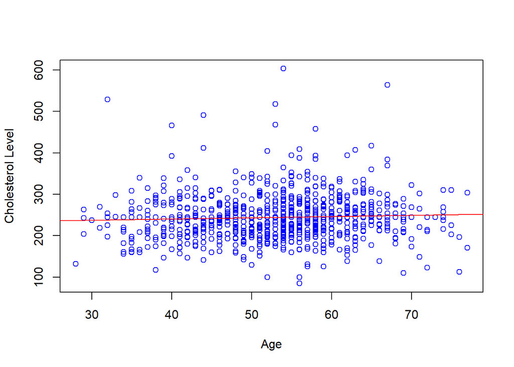

```r
{plot(data$Age, data$Cholesterol,
     col="blue",
     xlab='Age',
     ylab='Cholesterol Level')
  abline(lm(data$Cholesterol ~ data$Age), col="red")}
```

Iz ovog scatterplota vidimo gotovo nepostojeću korelaciju između dobi i razine kolesterola.

```r
lowCholesterolCnt = nrow(data[data$Cholesterol < 120,])
lowCholesterolCnt
```

```
## [1] 6
```

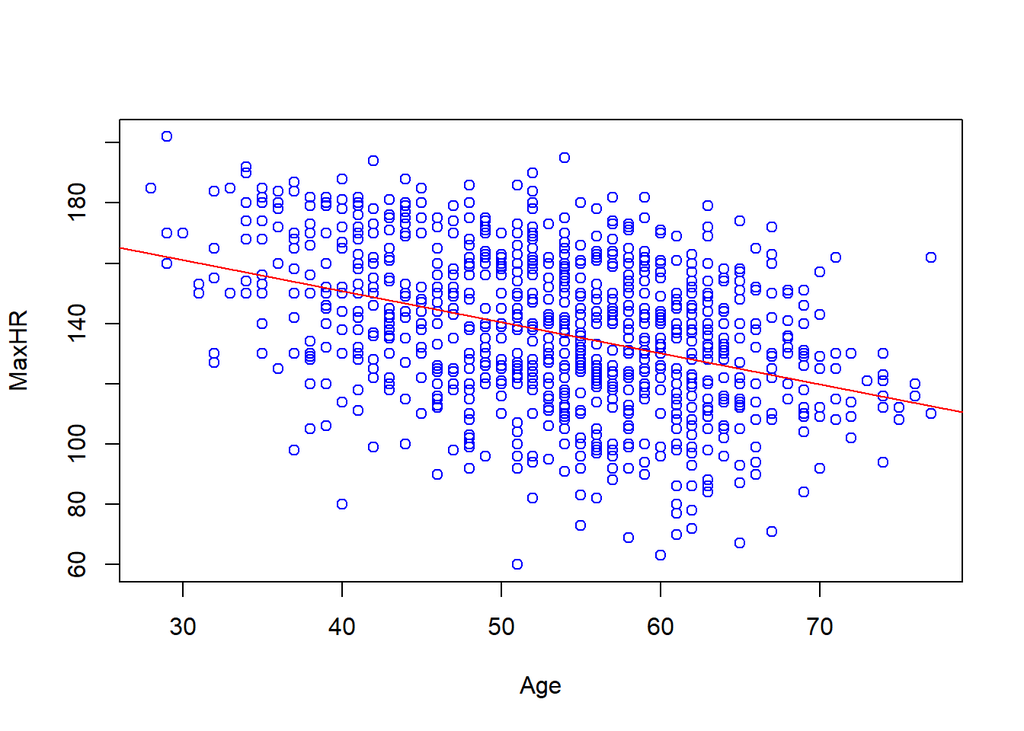

```r
x <- data$Age
y <- data$MaxHR

model = lm(y ~ x)
{plot(x, y,
     col="blue",
     xlab='Age',
     ylab='MaxHR')
abline(model, col = "red")}
```

Ovaj scatterplot ukazuje na slabu negativnu korelaciju između vrijednosti parametara MaxHR i Age.

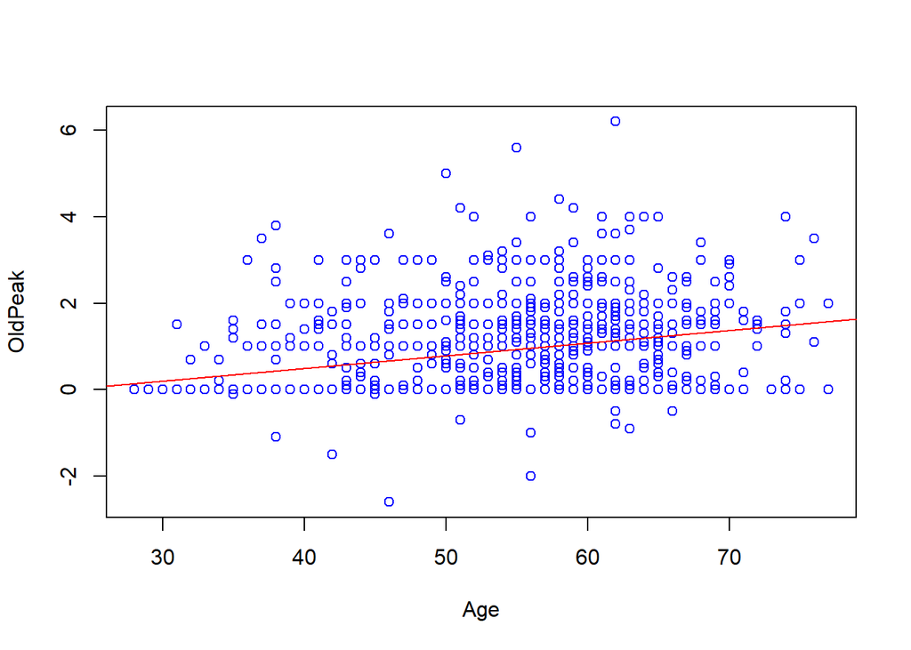

```r
{plot(data$Age, data$Oldpeak,
     col="blue",
     xlab='Age',
     ylab='OldPeak')

abline(lm(data$Oldpeak ~ data$Age), col = "red")}
```

Grafovi ukazuju na to da nam se najviše isplati postaviti pitanje o ovisnosti MaxHR o dobi (iako je ta korelacija također dosta blaga), jer ostale ovisnosti iz grafova izgledaju još više nekorelirano.

## Analiza ovisno o prisutnosti srčane bolesti

```r
library(tidyverse)

data %>% group_by(HeartDisease) %>% summarise(
  NumOfPatients = n(),
  FastingBSRatio = sum(FastingBS)/n(),
  ExerciseAnginaRatio = sum(ExerciseAngina)/n(),
  Mean.Age = mean(Age),
  Med.Age = median(Age),
  Mean.RestingBP = mean(RestingBP),
  Med.RestingBP = median(RestingBP),
  StdDev.RestingBP = sd(RestingBP),
  Mean.Cholesterol = mean(Cholesterol),
  StdDev.Cholesterol = sd(Cholesterol),
  Med.Cholesterol = median(Cholesterol),
  Mean.MaxHR = mean(MaxHR),
  StdDev.MaxHR = sd(MaxHR),
  Med.MaxHR = median(MaxHR),
  Mean.OldPeak = mean(Oldpeak),
  StdDev.OldPeak = sd(Oldpeak),
  Med.OldPeak = median(Oldpeak)
)
```

```
## # A tibble: 2 × 18
##   HeartDisease NumOfPatients FastingBSRatio ExerciseAnginaRatio Mean.Age Med.Age
##          <dbl>         <int>          <dbl>               <dbl>    <dbl>   <dbl>
## 1            0           410          0.107               0.134     50.6      51
## 2            1           508          0.335               0.622     55.9      57
## # ℹ 12 more variables: Mean.RestingBP <dbl>, Med.RestingBP <dbl>,
## #   StdDev.RestingBP <dbl>, Mean.Cholesterol <dbl>, StdDev.Cholesterol <dbl>,
## #   Med.Cholesterol <dbl>, Mean.MaxHR <dbl>, StdDev.MaxHR <dbl>,
## #   Med.MaxHR <dbl>, Mean.OldPeak <dbl>, StdDev.OldPeak <dbl>,
## #   Med.OldPeak <dbl>
```

Ovdje konkretno vidimo izračunate mjere srednjih vrijednosti parametara za srčane bolesnike i one koji to nisu. Vidimo da se vrijednosti parametara Cholesterol, MaxHR i OldPeak razlikuju po grupama, kao i udio onih s povišenim šećerom i onih s vježbom induciranom anginom. To bi moglo motivirati pitanja može li se na temelju vrijednosti takvih parametara predvidjeti postojanje srčane bolesti.

Najbolje je to prvo analizirati boxplot dijagramima, paralelno za srčane bolesnike i zdrave pacijente.

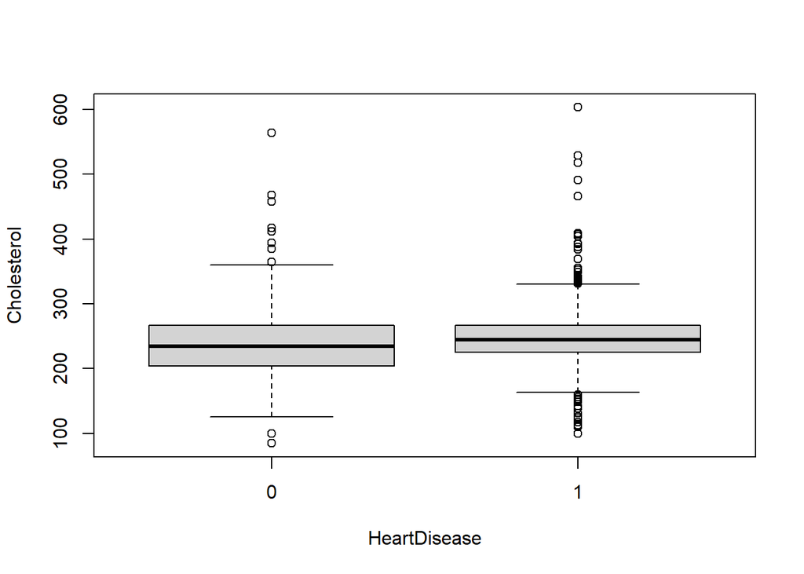

```r
boxplot(Cholesterol ~ HeartDisease, data = data)
```

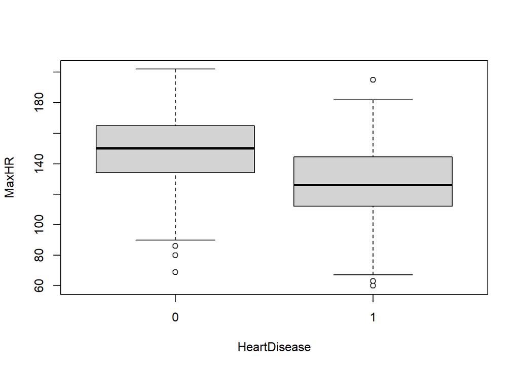

```r
boxplot(MaxHR ~ HeartDisease, data = data)
```

Ovaj bi boxplot mogao sugerirati na razliku u vrijednosti MaxHR parametra ovisno o tome je li pacijent srčani bolesnik ili ne - vidimo da za srčane bolesnike vrijedi da su vrijednosti MaxHR-a niže te da medijan bude manji te čak izvan vrijednosti prvog kvartila u skupini srčanih nebolesnika.

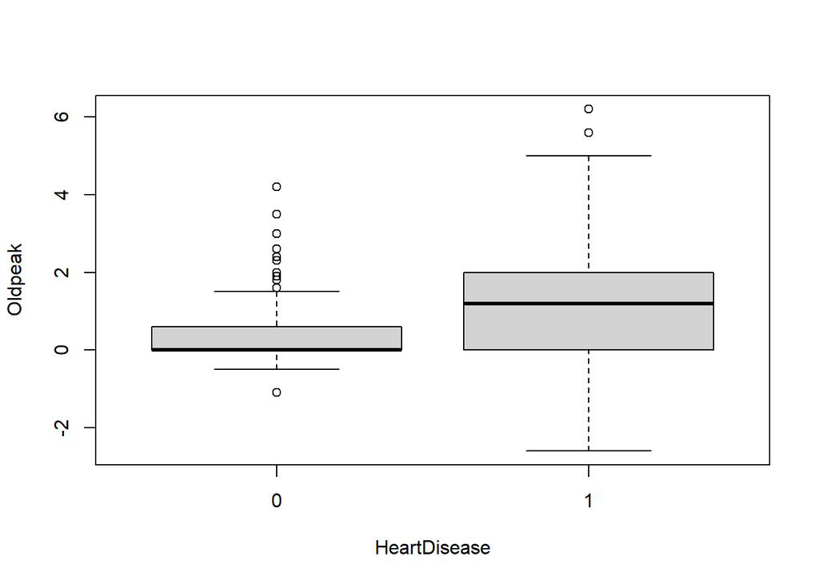

```r
boxplot(Oldpeak ~ HeartDisease, data = data)
```

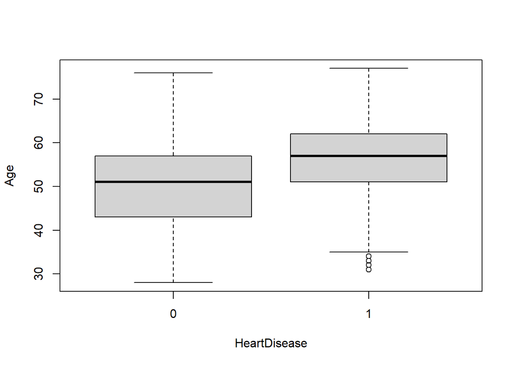

```r
boxplot(Age ~ HeartDisease, data = data)
```

```r
diseased <- data[data$HeartDisease == 1, ]
healthy <- data[data$HeartDisease == 0, ]
```

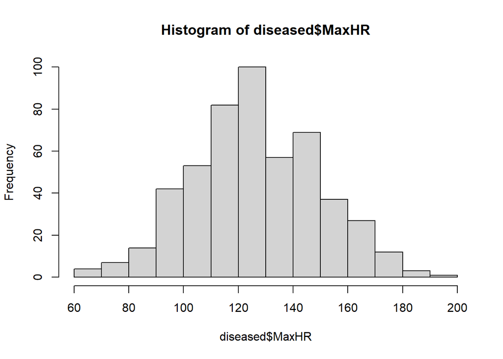

```r
hist(diseased$MaxHR)
```

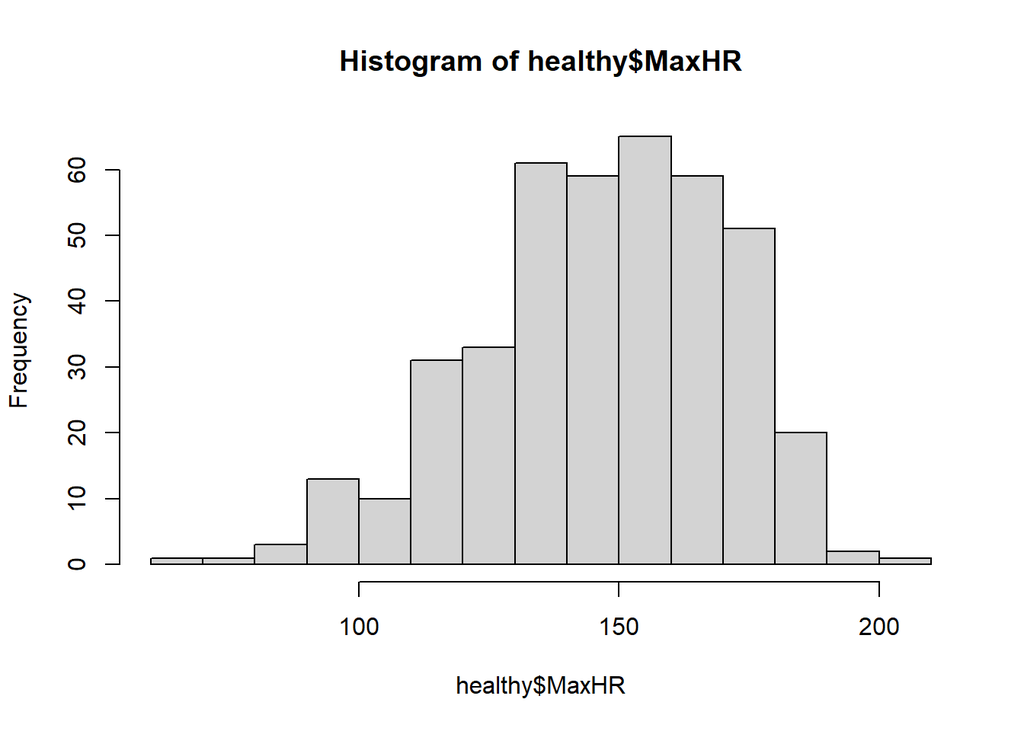

```r
hist(healthy$MaxHR)
```

## Analiza ovisno o razini šećera

```r
library(tidyverse)

data %>% group_by(FastingBS) %>% summarise(
  NumOfPatients = n(),
  HeartDiseaseRatio = sum(HeartDisease)/n(),
  Mean.Age = mean(Age),
  Med.Age = median(Age),
  Mean.RestingBP = mean(RestingBP),
  Med.RestingBP = median(RestingBP),
  StdDev.RestingBP = sd(RestingBP),
  Mean.Cholesterol = mean(Cholesterol),
  StdDev.Cholesterol = sd(Cholesterol),
  Med.Cholesterol = median(Cholesterol),
  Mean.MaxHR = mean(MaxHR),
  StdDev.MaxHR = sd(MaxHR),
  Med.MaxHR = median(MaxHR),
  Mean.OldPeak = mean(Oldpeak),
  StdDev.OldPeak = sd(Oldpeak),
  Med.OldPeak = median(Oldpeak)
)
```

```
## # A tibble: 2 × 17
##   FastingBS NumOfPatients HeartDiseaseRatio Mean.Age Med.Age Mean.RestingBP
##       <dbl>         <int>             <dbl>    <dbl>   <dbl>          <dbl>
## 1         0           704             0.480     52.5      53           132.
## 2         1           214             0.794     56.9      57           135.
## # ℹ 11 more variables: Med.RestingBP <dbl>, StdDev.RestingBP <dbl>,
## #   Mean.Cholesterol <dbl>, StdDev.Cholesterol <dbl>, Med.Cholesterol <dbl>,
## #   Mean.MaxHR <dbl>, StdDev.MaxHR <dbl>, Med.MaxHR <dbl>, Mean.OldPeak <dbl>,
## #   StdDev.OldPeak <dbl>, Med.OldPeak <dbl>
```

# Normalizacija numeričkih značajki

```r
unNormalizedData <- data
data[-c(2,3,6,7,9,11,12)] <- scale(data[-c(2,3,6,7,9,11,12)])
```

### ISTRAŽIVAČKA PITANJA

VAŽNA NAPOMENA: Alfa vrijednost određuje se prije provođenja statističkog testa; mi ćemo u svim testovima uzeti da je alfa = 0.05 odnosno 5%.

## 1. pitanje

# Postoji li razlika u maksimalnom broju otkucaja srca između pacijenata s anginom i onih bez angine?

Kako bismo odgovorili na ovo pitanje trebamo koristiti T-test za dva uzorka. Znamo da T-test ima neke osnovne pretpostavke koje moramo provjeriti, a moramo provjeriti i jesu li varijance podataka jednake ili različite. Prvo ćemo pogledati jesu li podatci uzorkovani iz normalne razdiobe, a nakon toga provesti F-test kako bismo utvrdili jesu li varijance jednake ili različite.

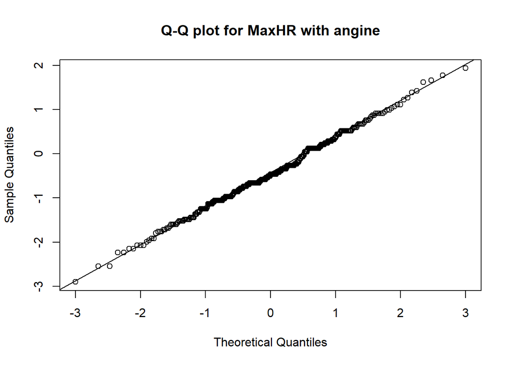

```r
withAngine <- data[data$ExerciseAngina == 1,]
withoutAngine <- data[data$ExerciseAngina == 0,]
maxHRWithAngine <- withAngine$MaxHR
maxHRWithoutAngine <- withoutAngine$MaxHR

# crtamo Q-Q plot kako bismo vidjeli odgovaraju li podatci normalnoj raspodjeli
qqnorm(maxHRWithAngine, main = "Q-Q plot for MaxHR with angine")
qqline(maxHRWithAngine)
```

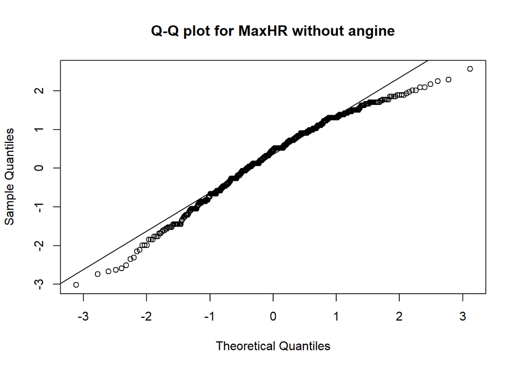

```r
qqnorm(maxHRWithoutAngine , main = "Q-Q plot for MaxHR without angine")
qqline(maxHRWithoutAngine)
```

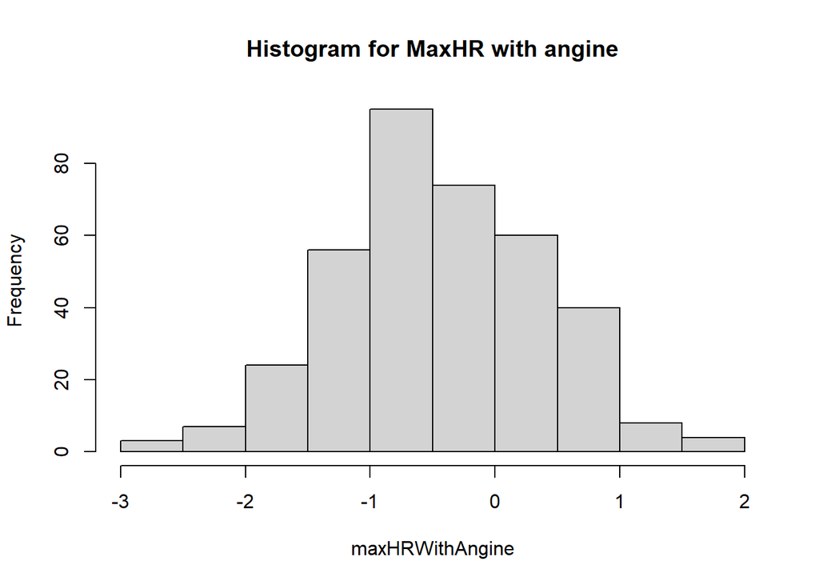

```r
# isto radimo s histogramima
hist(maxHRWithAngine, main = "Histogram for MaxHR with angine")
```

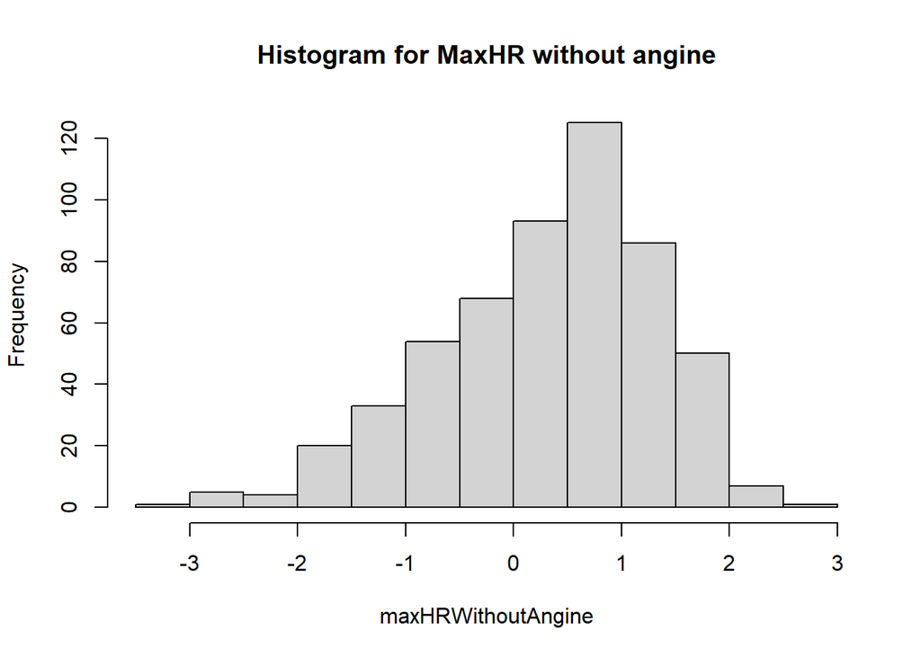

```r
hist(maxHRWithoutAngine, main = "Histogram for MaxHR without angine")
```

```r
library(nortest)
lillie.test(maxHRWithoutAngine)
```

```
##
##  Lilliefors (Kolmogorov-Smirnov) normality test
##
## data:  maxHRWithoutAngine
## D = 0.075696, p-value = 6.45e-08
```

```r
lillie.test(maxHRWithAngine)
```

```
##
##  Lilliefors (Kolmogorov-Smirnov) normality test
##
## data:  maxHRWithAngine
## D = 0.054536, p-value = 0.009992
```

Nastavljamo s F-testom kako bismo utvrdili jesu li varijance obaju skupova podataka jednake ili različite.

```r
var(maxHRWithoutAngine)
```

```
## [1] 1.011808
```

```r
var(maxHRWithAngine)
```

```
## [1] 0.645209
```

```r
var.test(maxHRWithAngine, maxHRWithoutAngine)
```

```
##
##  F test to compare two variances
##
## data:  maxHRWithAngine and maxHRWithoutAngine
## F = 0.63768, num df = 370, denom df = 546, p-value = 3.641e-06
## alternative hypothesis: true ratio of variances is not equal to 1
## 95 percent confidence interval:
##  0.5298767 0.7700287
## sample estimates:
## ratio of variances
##          0.6376795
```

Vidimo kako je p-vrijednost značajno manja od alfa = 5% pa zaključujemo da su varijance različite; radi toga koristimo T-test za dva uzorka s različitim varijancama.

```r
t.test(maxHRWithAngine, maxHRWithoutAngine, var.equal = FALSE)
```

```
##
##  Welch Two Sample t-test
##
## data:  maxHRWithAngine and maxHRWithoutAngine
## t = -12.594, df = 891.9, p-value < 2.2e-16
## alternative hypothesis: true difference in means is not equal to 0
## 95 percent confidence interval:
##  -0.8720165 -0.6368663
## sample estimates:
##  mean of x  mean of y
## -0.4495419  0.3048995
```

Iz rezultata vidimo kako je p-vrijednost značajno manja od alfa = 5% pa zaključujemo da postoji razlika u maksimalnom broju otkucaja srca između pacijenata s anginom i onih bez angine

## 2. pitanje

# Postoji li značajna razlika u starosti pacijenata s obzirom na različite vrste boli u prsima?

Zadatak je ispitati srednju vrijednost dobi pacijenata ovisno o vrstama boli u prsima. Kako bismo dobili neku početnu intuiciju, radimo boxplot prikaz.

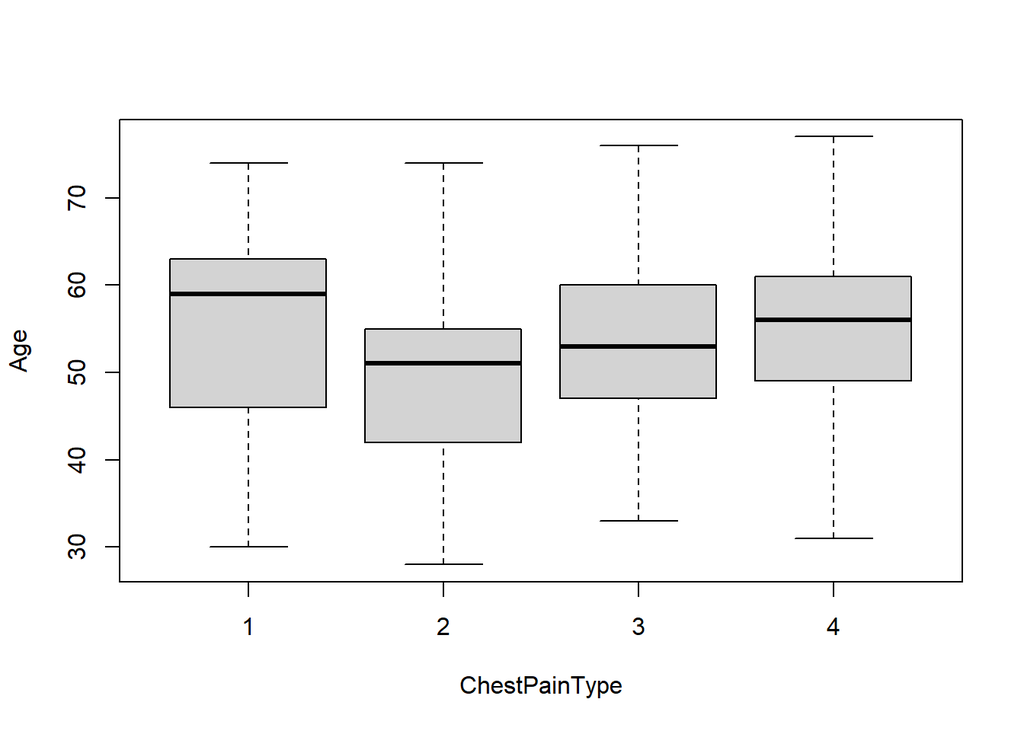

```r
boxplot(Age ~ ChestPainType, data = unNormalizedData)
```

Računamo uzoračku sredinu i varijancu pojedinih grupa. Vidimo da se sredine gotovo ne razlikuju, odskače eventualno sredina grupe 2.

```r
library(tidyverse)

unNormalizedData %>% group_by(ChestPainType) %>% summarise(
  NumOfPatients = n(),
  Mean.Age = mean(Age),
  Med.Age = median(Age),
  Std.Age = sd(Age),
  Var.Age = var(Age)
)
```

```
## # A tibble: 4 × 6
##   ChestPainType NumOfPatients Mean.Age Med.Age Std.Age Var.Age
##           <dbl>         <int>    <dbl>   <dbl>   <dbl>   <dbl>
## 1             1            46     54.8      59   11.4    131.
## 2             2           173     49.2      51    9.26    85.7
## 3             3           203     53.3      53    9.61    92.3
## 4             4           496     55.0      56    8.76    76.8
```

Test kojim bi ispitali jednakost ovih sredina jest ANOVA (analiza varijanci). Pretpostavke tog testa su nezavisnost, normalnost populacija grupa, kao i jednakost njihovih varijanci.

Kako bismo ispitali ovo treće, koristimo Bartlettov test. Nulta hipoteza tog testa jest da su varijance po svim grupama jednake, dok je alternativna hipoteza da za barem jedan par grupa vrijedi da to nije tako.

```r
bartlett.test(Age ~ ChestPainType, unNormalizedData)
```

```
##
##  Bartlett test of homogeneity of variances
##
## data:  Age by ChestPainType
## Bartlett's K-squared = 8.0402, df = 3, p-value = 0.04519
```

Na razini značajnosti od 5% bismo odbacili nultu hipotezu, odnosno podaci sugeriraju da varijance po grupama nisu iste.

Kako bismo ispitali normalnost podataka iz pojedinih grupa, vizualiziramo ih histogramima, Q-Q plotovima te naposlijetku radimo i Lillieforseovu inačicu Kolmogorov-Smirnovljevog testa.

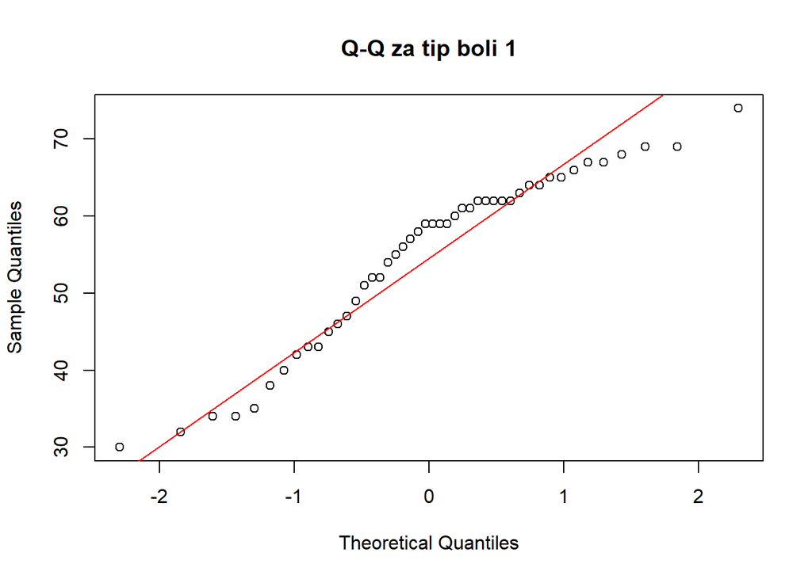

```r
agePainType1 <- unNormalizedData[unNormalizedData$ChestPainType == 1,]$Age
agePainType2 <- unNormalizedData[unNormalizedData$ChestPainType == 2,]$Age
agePainType3 <- unNormalizedData[unNormalizedData$ChestPainType == 3,]$Age
agePainType4 <- unNormalizedData[unNormalizedData$ChestPainType == 4,]$Age

{qqnorm(agePainType1, main = "Q-Q za tip boli 1")
 qqline(agePainType1, col = "red")}
```

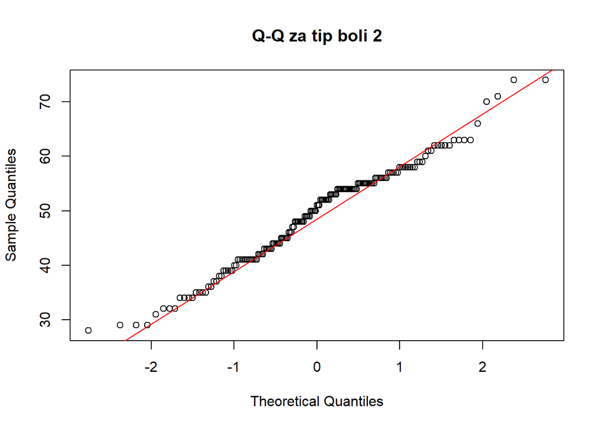

```r
{qqnorm(agePainType2, main = "Q-Q za tip boli 2")
 qqline(agePainType2, col = "red")}
```

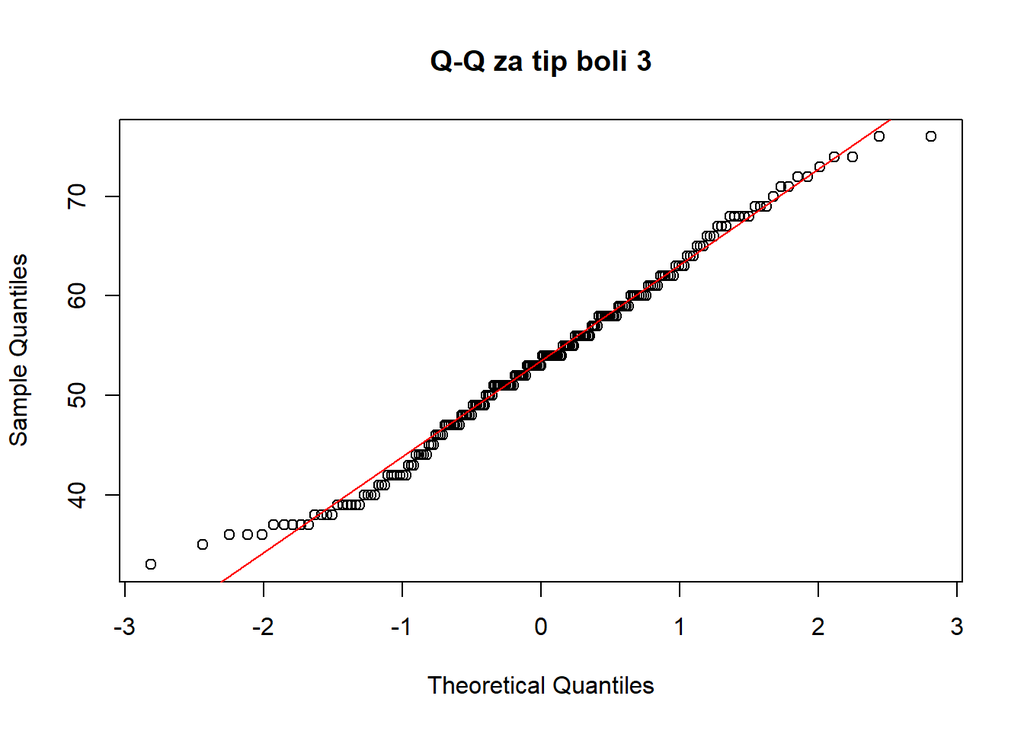

```r
{qqnorm(agePainType3, main = "Q-Q za tip boli 3")
 qqline(agePainType3, col = "red")}
```

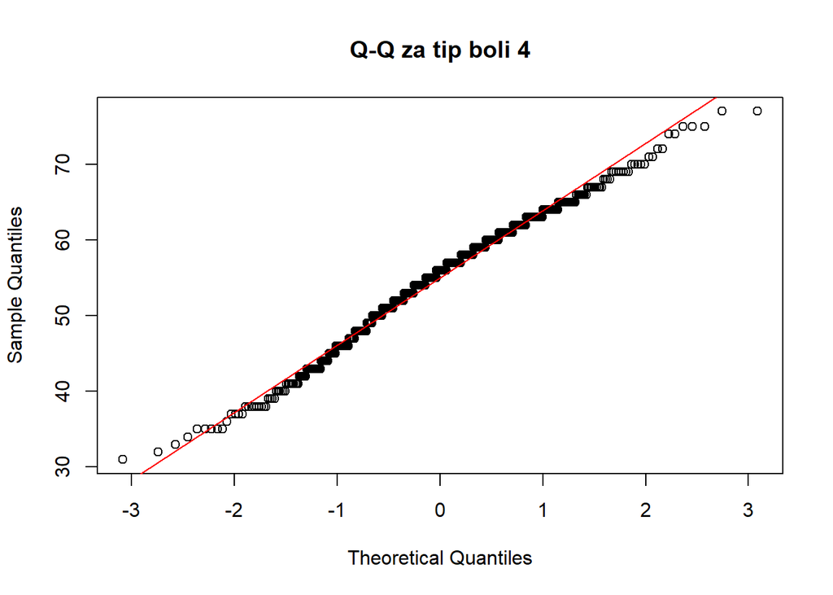

```r
{qqnorm(agePainType4, main = "Q-Q za tip boli 4")
 qqline(agePainType4, col = "red")}
```

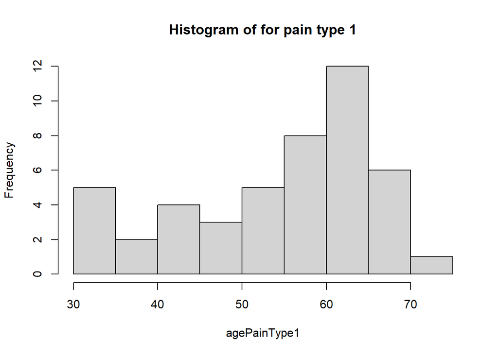

```r
hist(agePainType1, main = "Histogram of for pain type 1")
```

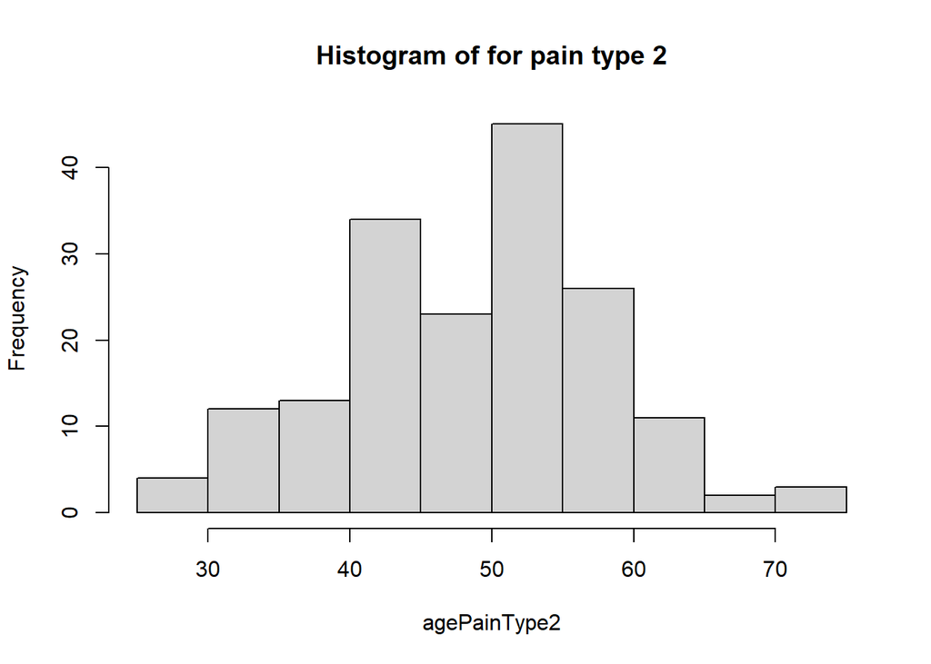

```r
hist(agePainType2, main = "Histogram of for pain type 2")
```

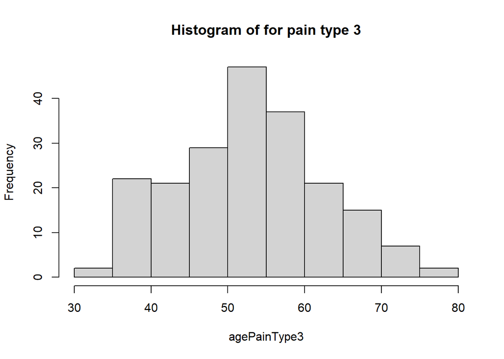

```r
hist(agePainType3, main = "Histogram of for pain type 3")
```

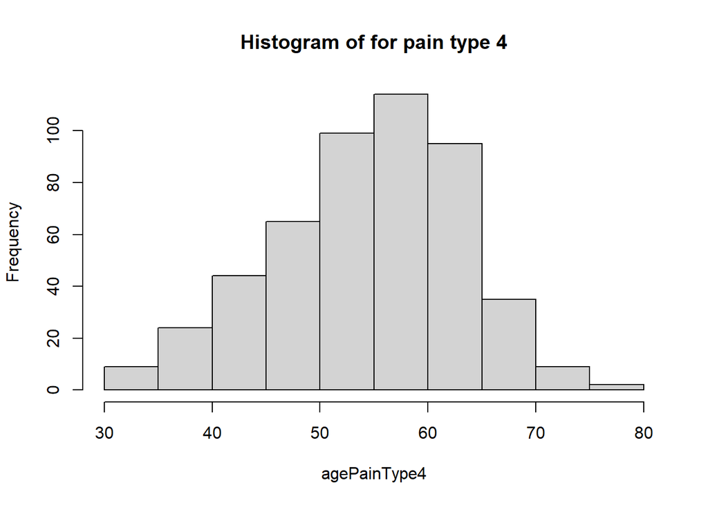

```r
hist(agePainType4, main = "Histogram of for pain type 4")
```

```r
library(nortest)
lillie.test(agePainType1)
```

```
##
##  Lilliefors (Kolmogorov-Smirnov) normality test
##
## data:  agePainType1
## D = 0.16402, p-value = 0.003304
```

```r
lillie.test(agePainType2)
```

```
##
##  Lilliefors (Kolmogorov-Smirnov) normality test
##
## data:  agePainType2
## D = 0.10261, p-value = 0.0001342
```

```r
lillie.test(agePainType3)
```

```
##
##  Lilliefors (Kolmogorov-Smirnov) normality test
##
## data:  agePainType3
## D = 0.047925, p-value = 0.3066
```

```r
lillie.test(agePainType4)
```

```
##
##  Lilliefors (Kolmogorov-Smirnov) normality test
##
## data:  agePainType4
## D = 0.06584, p-value = 2.409e-05
```

Vidimo da su p-vrijednosti Lillieforseove inačice sve osim za kategoriju 3 manje od 5%. Također ni grafovi ne sugeriraju normalnu razdiobu podataka.

Puno nas toga odvraća od parametarskog ANOVA testa, pa se odlučujemo za provedbu njegove neparametarske alternative - Kruskal-Wallisova testa. Uvjet za primjenjivost Kruskal-Wallisovog testa jest da je veličina svakog uzorka (grupe) barem 5. što je kod nas slučaj. Nulta hipoteza je da su sve sredine po grupama jednake, a alternativna da za barem jedan par grupa to ne vrijedi.

```r
kruskal.test(Age ~ ChestPainType, data=data)
```

```
##
##  Kruskal-Wallis rank sum test
##
## data:  Age by ChestPainType
## Kruskal-Wallis chi-squared = 48.599, df = 3, p-value = 1.588e-10
```

Vidimo da je p-vrijednost jako malena, što znači da odbacujemo nultu hipotezu, odnosno, podaci sugeriraju da postoji značajna razlika u starosti ovisno o tipu boli u prsima.

## 3. pitanje

# Možemo li predvidjeti prisutnost srčane bolesti na temelju maksimalnog broja otkucaja srca i starosti?

Za pronalazak odgovora na treće pitanje koristimo logističku regresiju. Linearna regresija nije dobar izbor jer je problem klasifikacijski. Linearna regresija loše klasificira jer funkcija pogreške kažnjava i točno klasificirane primjere koji su daleko od granice odluke te zbog toga stršeće vrijednosti mogu značajno utjecati na pomak granice odluke (čak i kada su točno klasificirane).

Za logističku regresiju trebamo provjeriti nekoliko pretpostavki: 1. Ne smije biti multikolinearnosti u podatcima 2. Podatci moraju biti nezavisni (ulazi su nezavisne varijable dok je izlaz y zavisna varijabla) 3. Nema nedostajućih vrijednosti i klase imaju balansirani broj primjera (u našem slučaju oba uvjeta su ispunjena, provjera je napravljena u fazi čišćenja podataka)

Prije provedbe logističke regresije poželjno je vizualizirati podatke kako bismo dobili bolji uvid u njih. U našem slučaju možemo koristiti graf raspršenja jer imamo samo dvije varijable.

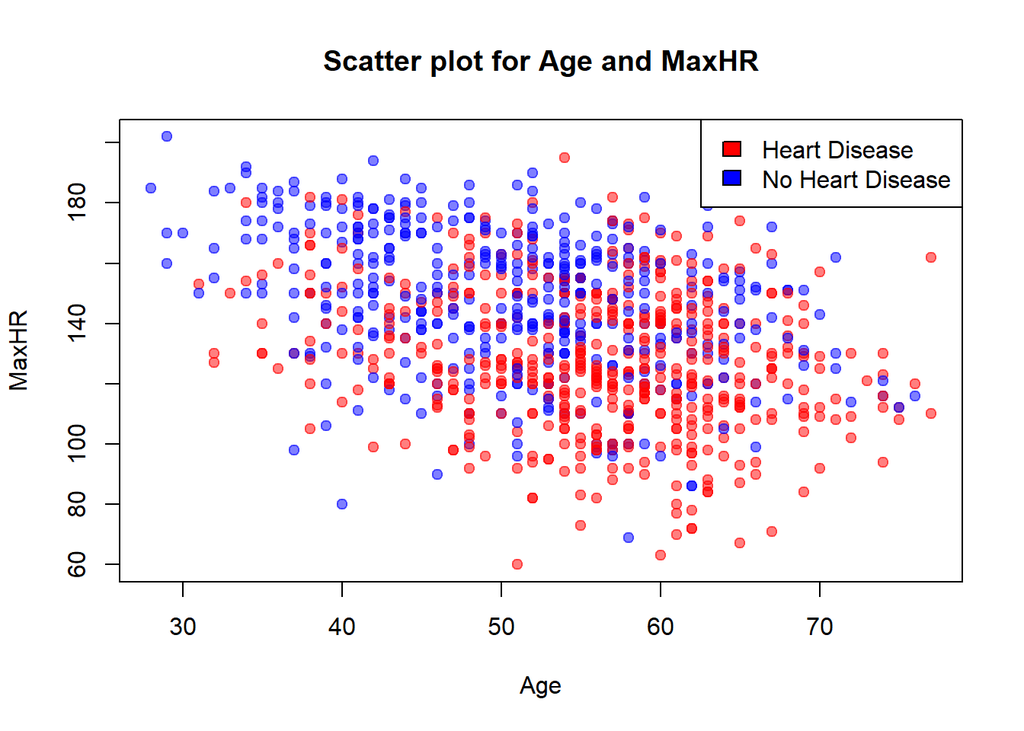

```r
colors <- ifelse(oldCategoricalData$HeartDisease == 1, rgb(1,0,0,0.5), rgb(0,0,1,0.5))
plot(oldCategoricalData$Age, oldCategoricalData$MaxHR, col = colors, main = "Scatter plot for Age and MaxHR", xlab = "Age", ylab = "MaxHR", pch = 19)
legend("topright", legend = c("Heart Disease", "No Heart Disease"), fill = c("red", "blue"))
```

Iz grafa je vidljivo kako su srčane bolesti rjeđe kod mlađih ljudi koji imaju veći maksimalan broj otkucaja srca, dok stariji ljudi s manjim maksimalnim brojem otkucaja srca češće imaju srčane bolesti.

# Provjera pretpostavki logističke regresije

Funkcijom cor tražimo korelaciju između naših dviju varijabli.

```r
library(ggcorrplot)

predictor <- data.frame(data$Age, data$MaxHR)
cor(predictor)
```

```
##              data.Age data.MaxHR
## data.Age    1.0000000 -0.3820447
## data.MaxHR -0.3820447  1.0000000
```

```r
#ggcorrplot(cor(predictor), hc.order = TRUE, type = "lower", lab = TRUE)
```

Dobili smo korelaciju od -0.38 što je relativno slaba korelacija, pa možemo nastaviti s provođenjem logističke regresije.

```r
logisticModel <- glm(HeartDisease ~ MaxHR + Age, data = data, family = binomial)
summary(logisticModel)
```

```
##
## Call:
## glm(formula = HeartDisease ~ MaxHR + Age, family = binomial,
##     data = data)
##
## Coefficients:
##             Estimate Std. Error z value Pr(>|z|)
## (Intercept)  0.25847    0.07373   3.505 0.000456 ***
## MaxHR       -0.82458    0.08708  -9.469  < 2e-16 ***
## Age          0.35662    0.08012   4.451 8.55e-06 ***
## ---
## Signif. codes:  0 '***' 0.001 '**' 0.01 '*' 0.05 '.' 0.1 ' ' 1
##
## (Dispersion parameter for binomial family taken to be 1)
##
##     Null deviance: 1262.1  on 917  degrees of freedom
## Residual deviance: 1082.6  on 915  degrees of freedom
## AIC: 1088.6
##
## Number of Fisher Scoring iterations: 3
```

Nakon što smo proveli logističku regresiju možemo analizirati dobivene rezultate.

Vidimo kako je koeficijent MaxHR jednak -0.83 što sugerira da se s povećanjem maksimalnog broja otkucaja srca smanjuje vjerojatnost imanja srčane bolesti. Koeficijent uz Age je 0.3566 što sugerira da starije osobe s većom vjerojatnošću imaju srčanu bolest. Dobiveni rezultati slažu se s vizualizacijom podataka koju smo napravili ranije.

P-vrijednosti su male: 2 * 10^-16 za MaxHR i 8.55 * 10^-6 za Age, iz čega možemo zaključiti kako oba koeficijenta imaju statistički značajan utjecaj.

# Predikcija

```r
library(pROC)
```

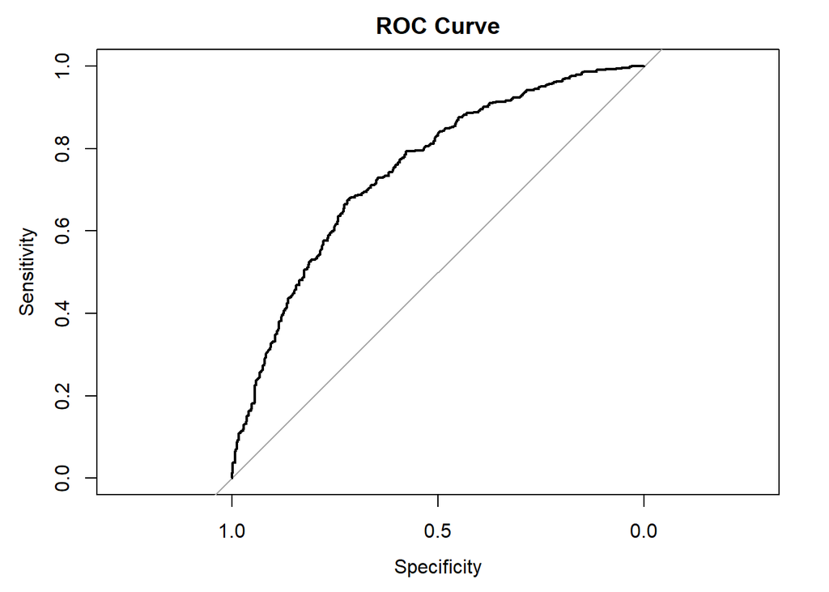

```r
# Predikcije
predictions <- predict(logisticModel, type = "response")
# ROC krivulja
roc_curve <- roc(data$HeartDisease, predictions)
plot(roc_curve, main = "ROC Curve")
```

```r
# AUC vrijednost
auc(roc_curve)
```

```
## Area under the curve: 0.7467
```

Tzv. “area under the curve” predstavlja površinu ispod ROC krivulje. Znamo kako je ROC krivulja jednostavno pravac pod kutem od 45 stupnjeva ako je predikcija potpuno slučajna. Što je veća površina ispod grafa, bolja je sposobnost predikcije. Idealno je AUC jednak 1.

Za naš slučaj AUC je 0.7467, iz čega zaključujemo kako naš model ima dobru sposobnost predikcije. Poboljšanje rezultata eventualno bismo mogli postići tako da bismo u predikciju dodali još relevatnih značajki.